# HSG Finance Committee Transparency Report Fall 2024

## Summary

In Fall 2024, HSG Finance Committee met 13 times for a total of 645 minutes.

There were two rounds of allocations:

- Main allocations: $16,090
- Special allocations*: $2,500

HSG funded 151 planned events across 28 HSOs. HSOs requested a total of $85,000; the overall budget for Fall 2024 was $18,590.

Breakdowns by event type, item type, and organization are included in this transparency report. Please use the survey at the end of this report to send us comments, suggestions, or questions about this report or HSG Finance Committee activities in general.

* *The HSG Executive Board voted to replace the annual spring Harris Gala with a less costly celebration. Historically, the Harris Gala cost over $30,000. This release of funds allowed the Finance Committee to hold special allocations in mid-quarter.*

## Allocations by Organization

The minimum amount received by any HSO was $100 and the maximum was $1420.

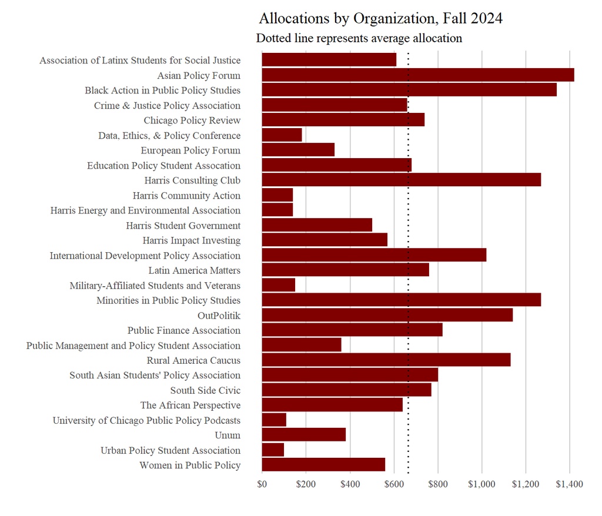

[figure not shown]

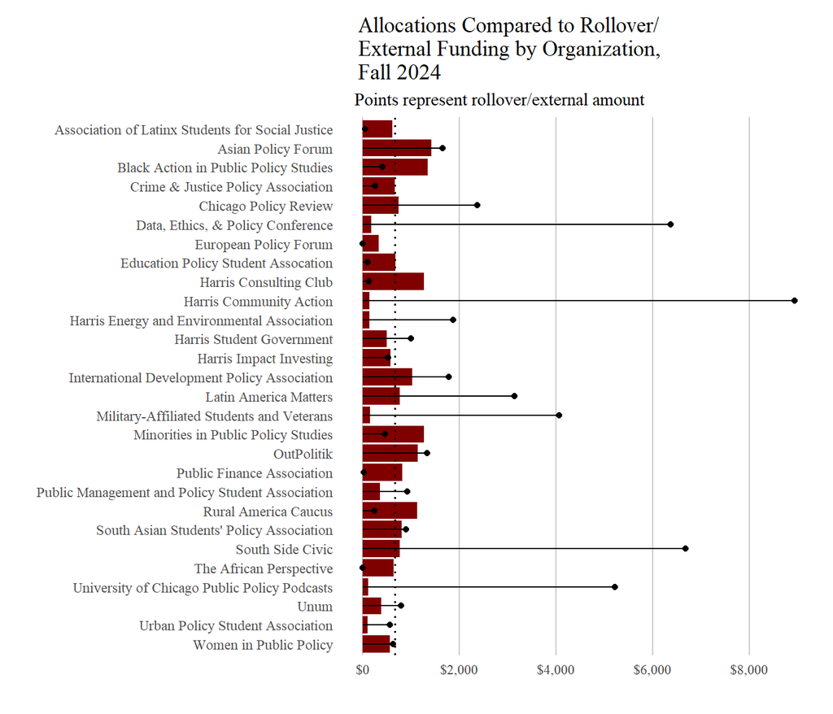

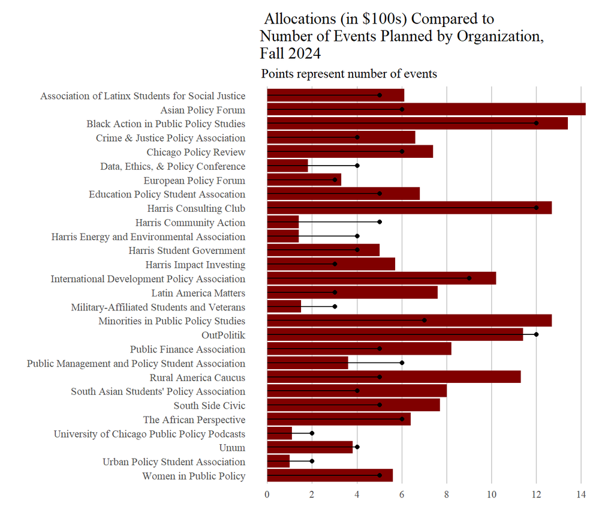

## Planned Spending by Event Type

We allocated funds on an organizational level, not on an item-by-item basis. The following analyses are estimates based on the proportion of funding requests dedicated to each category. Actual spending has not yet been calculated. For example, 38% of requests by Asian Policy Forum related to their annual Southeast Asian cultural show. We scaled this proportion by the final amount awarded to Asian Policy Forum, $1,420, to estimate the amount that would have been spent on cultural events. I also assumed that each organization would use at least 20% of their rollover (existing) funds this quarter.

Notation:

- **Social**: e.g., retreats, happy hours, mixers, study hours, and alumni events
- **Speaker**: e.g., presentations, lunch & learns, and panels, usually about policy topics
- **Community engagement**: e.g., volunteering and off-campus events
- **Promotion**: e.g., graphic design, and recruitment activities
- **Workshop**: e.g., career fairs and writing workshops

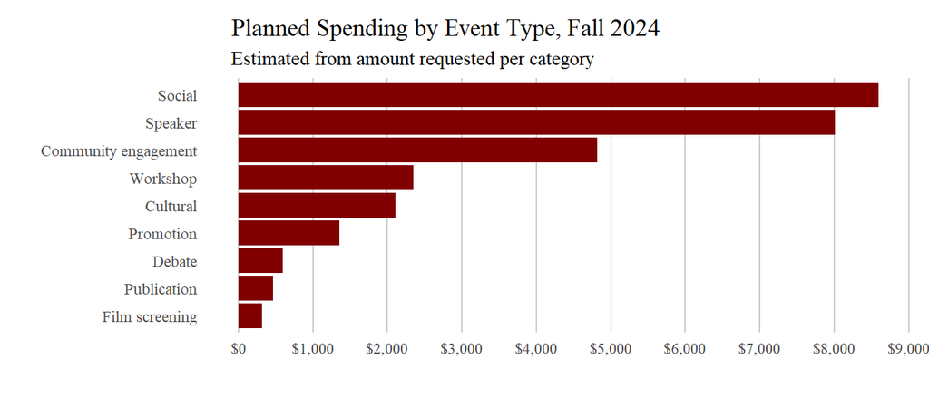

## Planned Spending by Item Type

See previous section for a description of how these items were calculated.

Notation:

- **Services**: e.g., bartending, space rental, transportation, event tickets, and food delivery
- **Gifts**: e.g., speaker honorariums, promotional merchandise, and raffle prizes
- **Reusable supplies**: e.g., board games and decorations
- **Non-reusable supplies**: e.g., utensils and firewood

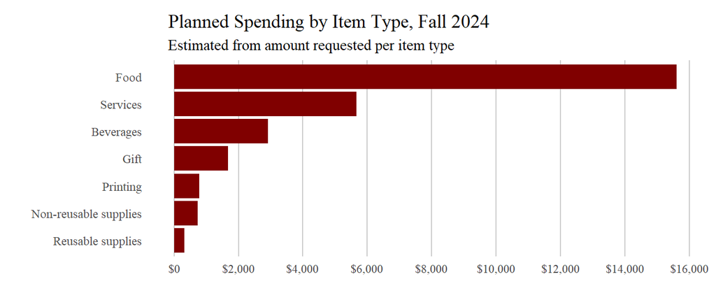

## Future improvements

Improvements for next quarter:

- **Expedite funding timelines**
  - HSOs reported unusually slow funding timelines, due to institutional knowledge loss from last year’s government. Next quarter, HSOs can expect to receive funding by Week 1.
- **Increase funding transparency**
  - HSOs reported being unclear on what criteria were being used to fund activities. For the Winter 2025 cycle, we released a new [budgeting template](https://tinyurl.com/4yx98367) and new [funding criteria](https://tinyurl.com/2bejj7pf) to address these issues.

## Survey

**We need your voice** to determine what types of events we, as the Harris student body, want to fund next quarter. Please fill the following [1-minute form](https://forms.gle/Jq5z4rwTVAKWb9re8) to let us know your opinion.

Sincerely,

Tony Jiang, Finance Committee Chair

Karen Yi, Second-Year Finance Committee Member

Andrea Kimpson, Second-Year Finance Committee Member

Shivani Patel, Second-Year Finance Committee Member

Faris Alrakhis, First-Year Finance Committee Member

Moe Alsharif, First-Year Finance Committee Member

Tiffany Tu, First-Year Finance Committee Member